# Session2: Introduction to Data Frame

### Subset a dataframe: Conditional

```r
## Select observations with Sepal.Width > 3
iris[iris$Sepal.Width > 3, ]
```

```
       Sepal.Length Sepal.Width Petal.Length Petal.Width    Species
Row1            5.1         3.5          1.4         0.2     setosa
Row3            4.7         3.2          1.3         0.2     setosa
Row4            4.6         3.1          1.5         0.2     setosa
Row5            5.0         3.6          1.4         0.2     setosa
Row6            5.4         3.9          1.7         0.4     setosa
Row7            4.6         3.4          1.4         0.3     setosa
Row8            5.0         3.4          1.5         0.2     setosa
Row10           4.9         3.1          1.5         0.1     setosa
Row11           5.4         3.7          1.5         0.2     setosa
Row12           4.8         3.4          1.6         0.2     setosa
Row15           5.8         4.0          1.2         0.2     setosa
Row16           5.7         4.4          1.5         0.4     setosa
Row17           5.4         3.9          1.3         0.4     setosa
Row18           5.1         3.5          1.4         0.3     setosa
Row19           5.7         3.8          1.7         0.3     setosa
Row20           5.1         3.8          1.5         0.3     setosa
Row21           5.4         3.4          1.7         0.2     setosa
Row22           5.1         3.7          1.5         0.4     setosa
Row23           4.6         3.6          1.0         0.2     setosa
Row24           5.1         3.3          1.7         0.5     setosa
Row25           4.8         3.4          1.9         0.2     setosa
Row27           5.0         3.4          1.6         0.4     setosa
Row28           5.2         3.5          1.5         0.2     setosa
Row29           5.2         3.4          1.4         0.2     setosa
Row30           4.7         3.2          1.6         0.2     setosa
Row31           4.8         3.1          1.6         0.2     setosa
Row32           5.4         3.4          1.5         0.4     setosa
Row33           5.2         4.1          1.5         0.1     setosa
Row34           5.5         4.2          1.4         0.2     setosa
Row35           4.9         3.1          1.5         0.2     setosa
Row36           5.0         3.2          1.2         0.2     setosa
Row37           5.5         3.5          1.3         0.2     setosa
Row38           4.9         3.6          1.4         0.1     setosa
Row40           5.1         3.4          1.5         0.2     setosa
Row41           5.0         3.5          1.3         0.3     setosa
Row43           4.4         3.2          1.3         0.2     setosa
Row44           5.0         3.5          1.6         0.6     setosa
Row45           5.1         3.8          1.9         0.4     setosa
Row47           5.1         3.8          1.6         0.2     setosa
```

[output cut: 13 more lines]

```
Row111          6.5         3.2          5.1         2.0  virginica
Row116          6.4         3.2          5.3         2.3  virginica
Row118          7.7         3.8          6.7         2.2  virginica
Row121          6.9         3.2          5.7         2.3  virginica
Row125          6.7         3.3          5.7         2.1  virginica
Row126          7.2         3.2          6.0         1.8  virginica
Row132          7.9         3.8          6.4         2.0  virginica
Row137          6.3         3.4          5.6         2.4  virginica
Row138          6.4         3.1          5.5         1.8  virginica
Row140          6.9         3.1          5.4         2.1  virginica
Row141          6.7         3.1          5.6         2.4  virginica
Row142          6.9         3.1          5.1         2.3  virginica
Row144          6.8         3.2          5.9         2.3  virginica
Row145          6.7         3.3          5.7         2.5  virginica
Row149          6.2         3.4          5.4         2.3  virginica
```

### Evaluate a characteristic

```r
## Get proportion of each species with Sepal.Width > 3
table(iris[iris$Sepal.Width > 3, ]$Species)
```

```
    setosa versicolor  virginica
        42          8         17
```

### Pie chart

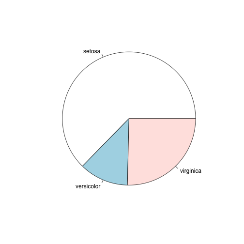

```r
## Pie chart for plants with Sepal.Width > 3
pie(table(iris[iris$Sepal.Width > 3, ]$Species))
```

### Statistical analysis: Anova

```r
## Fit a model
iris.aov <- aov(Petal.Width ~ Species, data = iris)
summary(iris.aov)
```

```
             Df Sum Sq Mean Sq F value Pr(>F)
Species       2  80.41   40.21     960 <2e-16 ***
Residuals   147   6.16    0.04
---
Signif. codes:  0 '***' 0.001 '**' 0.01 '*' 0.05 '.' 0.1 ' ' 1
```

### Statistical analysis: Pairwise Comparison

```r
## Fit a model
TukeyHSD(iris.aov)
```

```
  Tukey multiple comparisons of means
    95% family-wise confidence level

Fit: aov(formula = Petal.Width ~ Species, data = iris)

$Species
                     diff       lwr       upr p adj
versicolor-setosa    1.08 0.9830903 1.1769097     0
virginica-setosa     1.78 1.6830903 1.8769097     0
virginica-versicolor 0.70 0.6030903 0.7969097     0
```

### Statistical analysis: Plotting

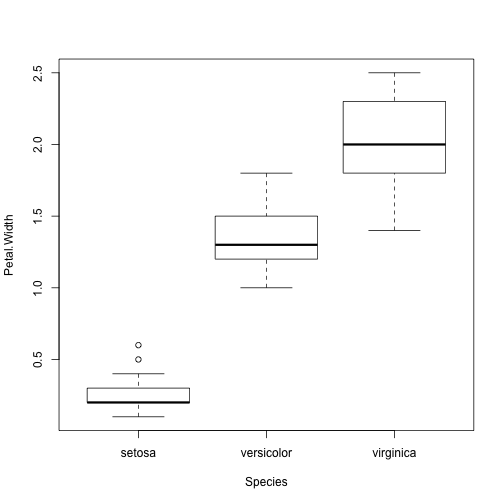

```r
## Boxplot
boxplot(Petal.Width ~ Species, data = iris)
```

### Advantage of Long Format

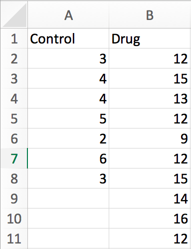

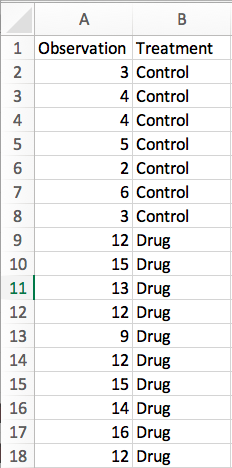

### Plotting your experiment

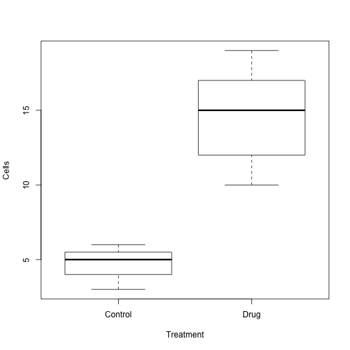

```r
Experiment <- data.frame(Cells = c(3, 5, 6, 10, 12, 15, 17, 19),
                         Treatment = c(rep("Control", 3), rep("Drug", 5)))

boxplot(Cells ~ Treatment, data = Experiment)
```

### Analysis of your experiment

```r
## t-test
t.test(Cells ~ Treatment, data = Experiment)
```

```
    Welch Two Sample t-test

data:  Cells by Treatment
t = -5.3574, df = 5.7056, p-value = 0.002029
alternative hypothesis: true difference in means is not equal to 0
95 percent confidence interval:
 -14.527576  -5.339091
sample estimates:
mean in group Control    mean in group Drug
             4.666667             14.600000
```

### Summary

- Data Frame is powerful data structure in R
- Data Frame is 2-D
  - Columns correspond to one feature (characteristic)
  - Row correspond to one case (sample)
- Subsetting is [row, column] (can be number or name or **conditional**)
  - Special case: **df$column**
- Qualitative Features are treated as Factors (Groups)
- Formula (Quantitative ~ Qualitative) allow comparisons between groups

### Next Session

- Cleaning up

```r
is.SWg3 <- iris$Sepal.Width > 3
obs.SWg3 <- iris[iris$Sepal.Width > 3, ]
species.SWg3 <- obsSWg3$Species
table(species.SWg3)
pie(species.SWg3)
```

```r
pie(table(iris[iris$Sepal.Width > 3, ]$Species))
```

- Pipe and dplyr

```r
iris %>%
    filter(Sepal.Width > 3) %>%
    select(Species) %>%
    table %>%
    pie
```

### Last Slide

For more details on authoring R presentations please visit https://support.rstudio.com/hc/en-us/articles/200486468.